# ExplanationAttempt

Includes:

1. “Another attempt at an intuitive explanation of….”: semi-qualitative description of dynamics affecting strangely low accuracy
2. “Where do the numbers come from…?”: brief description of method used to get distributions described in the first section; expansion into general formula
3. “Probabilities for non-deciding agent”: formula for the probability of a second agent having any particular outcome conditioned on accuracy/inaccuracy of first decision
4. “Probabilities of correct/incorrect first decisions”: Uses the above to give probability formulas for accuracy as functions of $\theta$ and $c$ when $n=2$; shows that this accuracy must be less than the previous $\frac{1}{1+e^{-\theta}}$ for $0<c<1$.

## Another attempt at an intuitive explanation of …

We know that in completely correlated and completely uncorrelated cases we recover the anticipated behavior of $P(y_{FD} = \theta|H^+) = \frac{1}{1+e^{-\theta}}$; therefore, we consider situations in which there is at least one correlated and at least one uncorrelated (independent) observation set. The following is solely for the case in which all agents make a correlated or independent observation on each timestep, and is only detailed for situations in which the first decision occurs on the first possible timestep. I believe the general principle to hold for decisions at later timesteps, but have yet to fill in the details. The $n = 2, \theta = 2, T = \theta = 2$ case is used as an example, with the assumption that $p>0,s>0,q>0$.

We investigate the behavior of a single agent *who is not the first decider*: given that this agent has been subjected to an observation in the direction of the first decision, how difficult is it for that agent to ‘recover’ to the position in which they now find themselves at the time of the first decision? This ‘difficulty’ depends on the probabilities of the needed observations and the number of ways these needed observations can be ordered.

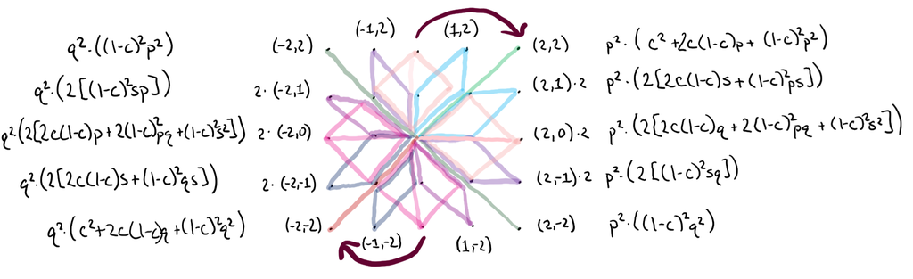

In our case of symmetric thresholds, there is a distribution to the number of ways each final outcome can be achieved that is weighted in the direction of the first decision (first decision is either $2$ or $-2$):

| Right First Decision | Right First Decision (2,2) | Right First Decision (2,1) | Right First Decision (2,0) | Right First Decision (2,-1) | Right First Decision (2,-2) |
| --- | --- | --- | --- | --- | --- |
| Total | 4 | 6 | 10 | 2 | 1 |

| Wrong First Decision | Wrong First Decision (-2,2) | Wrong First Decision (-2,1) | Wrong First Decision (-2,0) | Wrong First Decision (-2,-1) | Wrong First Decision (-2,-2) |
| --- | --- | --- | --- | --- | --- |
| Total | 1 | 2 | 10 | 6 | 4 |

These distributions can be further broken down into the ways corellated and independent observations can be combined. The breakdowns are again symmetric (anti-symmetric?) across right and wrong first decisions:

| Right First Decision | Right First Decision (2,2) | Right First Decision (2,1) | Right First Decision (2,0) | Right First Decision (2,-1) | Right First Decision (2,-2) |
| --- | --- | --- | --- | --- | --- |
| **paths** |  |  |  |  |  |
| c^2 | 1 | 0 | 0 | 0 | 0 |
| c(1-c) | 2 | 4 | 4 | 0 | 0 |
| (1-c)^2 | 1 | 2 | 6 | 2 | 1 |
| **sum** |  |  |  |  |  |
| Total | 4 | 6 | 10 | 2 | 1 |

| Wrong First Decision | Wrong First Decision (-2,2) | Wrong First Decision (-2,1) | Wrong First Decision (-2,0) | Wrong First Decision (-2,-1) | Wrong First Decision (-2,-2) |
| --- | --- | --- | --- | --- | --- |
| **paths** |  |  |  |  |  |
| c^2 | 0 | 0 | 0 | 0 | 1 |
| c(1-c) | 0 | 0 | 4 | 4 | 2 |
| (1-c)^2 | 1 | 2 | 6 | 2 | 1 |
| **sum** |  |  |  |  |  |
| Total | 1 | 2 | 10 | 6 | 4 |

That the $c^2$ and $(1-c)^2$ paths conform to the anticipated $P(y_{FD} = \theta|H^+) = \frac{1}{1+e^{-\theta}}$ makes sense: in the $(1-c)^2$ case, the distributions for the actions of the non-deciding agent are perfectly balanced, and in the $c^2$ we essentially have a single agent. Any deviation from the anticipated result, if such deviation exists, must arise in the mixed terms whose distributions are more weighted toward the middle with a slight bias in the direction of the first decision.

Returning to the question of ‘recovery’:

If we have an environmental current moving in the correct direction, we can suppose that an agent who has been ‘dragged’ by a correlated observation in the correct direction will find it easier to move further in the correct direction or to stay still than to move ‘against the current’ in the wrong direction. Similarly, an agent who has been ‘dragged’ in the wrong direction by a correlated observation will find it again easier to move in the correct direction or to stay still than to move further in the wrong direction.

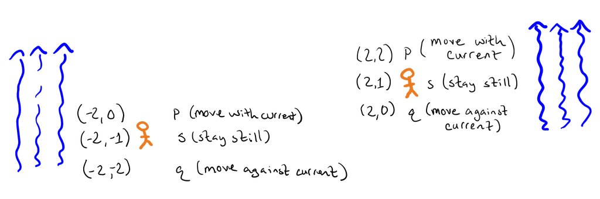

Options for Left: agent pulled in wrong direction and Right: agent pulled in correct direction by one correlated observation

This fairly obvious observation becomes more relevant when we consider the *number of ways* each of these outcomes can come about in a situation with at least one correlated and one uncorrelated observation (for our case, the $c(1-c)$ terms):

| Right First Decision | Right First Decision (2,2) | Right First Decision (2,1) | Right First Decision (2,0) | Right First Decision (2,-1) | Right First Decision (2,-2) |
| --- | --- | --- | --- | --- | --- |
| c(1-c) | 2 | 4 | 4 | 0 | 0 |

| Wrong First Decision | Wrong First Decision (-2,2) | Wrong First Decision (-2,1) | Wrong First Decision (-2,0) | Wrong First Decision (-2,-1) | Wrong First Decision (-2,-2) |
| --- | --- | --- | --- | --- | --- |
| c(1-c) | 0 | 0 | 4 | 4 | 2 |

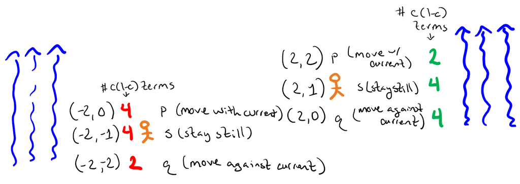

Options for Left: agent pulled in wrong direction and Right: agent pulled in correct direction by one correlated observation

The distribution of ways each outcome could come about favors the ‘middle’ outcomes over the edges. Moving ‘with the current’ is more likely to land our agent in one of these distributionally favored middle zones if they start (have been dragged along by one correlated observation) in a negative direction. While the relative weight of each of the blue rows varies with $c$, each of them retains this property, thus preserving the tendency whenever $0 <c < 1$.

This is in accord with the finding that when both agents make the same decision simultaneously, the decision is more likely to be accurate: it is easier for a ‘dragged along’ agent at $1$ to proceed with the current to $2$ than it is for a dragged along agent at $-1$ to go back against the current to $-2$, and the multipliers at the endpoints $(2,2)$ and $(-2,-2)$ are the same. But the multipliers on the middling points $(2,1)$, $(2,0)$, $(-2,0)$ and $(-2,-1)$ are much larger, and there the current favors those who had initially been dragged in the wrong direction and thus started further upstream.

Adding more agents increases the complexity of the final behavior, but each added agent will behave according to the principal that when there is at least one correlated and one independent observation, a ‘recovering’ agent is more likely to end up in the middle zones where the larger probability of moving ‘with the current’ (making observation $p$ or $s$) is multiplied by a larger (potentially much larger) coefficient after an incorrect correlated observation. The ‘distributional favoring’ of the middle zones continues as one increases $\theta$.

Below are number of orderings distributions for $n=2, \theta = 3$ and $n= 2, \theta = 4$; the weighting of the distributions slightly toward the first decision with peaks just to the side of center persists and, in fact, becomes more exaggerated.

For $n=2,\theta = 3$:

[output not shown]

[output not shown]

For $n=2,\theta = 4$:

| Right First Decision | Right First Decision (4,4) | Right First Decision (4,3) | Right First Decision (4,2) | Right First Decision (4,1) | Right First Decision (4,0) | Right First Decision (4,-1) | Right First Decision (4,-2) | Right First Decision (4,-3) | Right First Decision (4,-4) | Wrong First Decision (-4,4) | Wrong First Decision (-4,3) | Wrong First Decision (-4,2) | Wrong First Decision (-4,1) | Wrong First Decision (-4,0) | Wrong First Decision (-4,-1) | Wrong First Decision (-4,-2) | Wrong First Decision (-4,-3) | Wrong First Decision (-4,-4) |
| --- | --- | --- | --- | --- | --- | --- | --- | --- | --- | --- | --- | --- | --- | --- | --- | --- | --- | --- |
| **paths** |  |  |  |  |  |  |  |  |  |  |  |  |  |  |  |  |  |  |
| c^4 | 1 | 0 | 0 | 0 | 0 | 0 | 0 | 0 | 0 | 0 | 0 | 0 | 0 | 0 | 0 | 0 | 0 | 1 |
| c^3(1-c) | 4 | 8 | 8 | 0 | 0 | 0 | 0 | 0 | 0 | 0 | 0 | 0 | 0 | 0 | 0 | 8 | 8 | 4 |
| c^2 (1-c)^2 | 6 | 24 | 36 | 24 | 12 | 0 | 0 | 0 | 0 | 0 | 0 | 0 | 0 | 12 | 24 | 36 | 24 | 6 |
| c(1-c)^3 | 4 | 24 | 48 | 56 | 24 | 24 | 8 | 0 | 0 | 0 | 0 | 8 | 24 | 24 | 56 | 48 | 24 | 4 |
| (1-c)^4 | 1 | 8 | 20 | 32 | 38 | 32 | 20 | 8 | 2 | 2 | 8 | 20 | 32 | 38 | 32 | 20 | 8 | 1 |
| **sum** |  |  |  |  |  |  |  |  |  |  |  |  |  |  |  |  |  |  |
| Total | 16 | 64 | 112 | 112 | 74 | 56 | 28 | 8 | 2 | 2 | 8 | 28 | 56 | 74 | 112 | 112 | 64 | 16 |

## Where do the numbers come from…?

Yay, combinatorics.

For a single agent who is not the first decider, we take the number of possible orderings of the possible steps resulting in an outcome, accounting for the number of identical steps. Suppose, for example, we are interested in the outcome $(4,3)$ for the system in which $\theta = 4$ and the row in which there are $2$ correlated and $2$ independent observations. The steps needed for the non-deciding agent to arrive at endpoint $3$ are $p_c, p_c, p_{(1-c)},s_{(1-c)}$ where the subscripts $c$, $(1-c)$ indicate correlated or independent observations. Then our possible orderings are
$$\frac{\text{All possible orderings}}{(\text{# cor. steps})!(\text{# ind. moves toward first decision})!(\text{# ind. non-movements})!(\text{# ind. moves away from first decision})!}$$
$$= \frac{\text{All possible orderings}}{(\text{#}p_c \text{ or #} q_c)!(\text{#}p_{(1-c)}\text{ or #}q_{(1-c)}))!(\text{#}s_{(1-c)})!(\text{#}q_{(1-c)}\text{ or #}p_{(1-c)})!}$$
$$= \frac{_4\mathbf{P}_4}{2!1!1!0!} = 12 .$$

Because we consider the outcomes $(4,3)$ and $(3,4)$ to be equivalent, we double this to get $24$.

Generally:

Let $k$ be the number of independent observations a non-first-decider agent has made, and let $r$ be the distance between this agent’s belief and the first decider’s belief at the time of the first decision. In our example above, we had $k = 2$ and $r = 1$ ($\theta -r = 4-1 = 3$). Then we can say
$$\text{# effective orderings} \geq \frac{_\theta \mathbf{P}_\theta}{(\theta-k)!(|k-r|)!(k-|k-r|)!0!}(\text{# equivalent outcomes})$$
where $|k-r| = \text{dist}{((\theta-k),(\theta-r))} = \text{dist}{((\text{belief after correlated observations}),(\text{belief at time of first decision}))}$.

Why the inequality? Consider the values $\theta = 5$, $k = 4$, $r = 3$. Then our outcome at the time of the first decision is $(5,2)$ (equivalently, $(2,5)$) and the possible set of steps leading to this that maximises the number of $s_{(1-c)}$ observations (which corresponds to the formula above) is $p_c,p_{(1-c)},s_{(1-c)},s_{(1-c)},s_{(1-c)}$:
$$\frac{_\theta \mathbf{P}_\theta}{(\theta-k)!(|k-r|)!(k-|k-r|)!0!} = \frac{_5\mathbf{P}_5}{3!}.$$
However, another set of possible observations exists: $p_c,p_{(1-c)},s_{(1-c)},p_{(1-c)},q_{(1-c)}$ for which the above formula becomes
$$\frac{_\theta \mathbf{P}_\theta}{(\theta-k)!(|k-r|+1)!(k-|k-r| -2)!1!} = \frac{_5\mathbf{P}_5}{2!}.$$
In general, in any possible set of observations two $s_{(1-c)}$ observations may be replaced by a set of one $p_{(1-c)}$ and one $q_{(1-c)}$ observation, resulting in the more complete formula for the number of orderings for a specific outcome with a given number of independent observations $g(\theta,k,r)$ where $m$ is the number of times we perform this substitution:
$$g(\theta,k,r) = \sum_{m=0}^{\text{floor}((k-|k-r|)/2)}\frac{_\theta \mathbf{P}_\theta}{(\theta-k)!(|k-r|+m)!(k-|k-r| -2m)!m!},$$
assuming the outcome is possible with the given number of independent observations and an earliest possible first decision (a first decision occurring on the $\theta^{th}$ timestep.)

## Probabilities for non-deciding agent

The probability of a certain outcome given an incorrect first decision may be expressed as
$$g_q(\theta,r,k) = \delta (r,k) c^{\theta-k}(1-c)^k\frac{_\theta \mathbf{P}_\theta}{(\theta-k)!}\sum_{m=0}^{\text{floor}((k-|k-r|)/2)}\frac{ q^{\text{max}(k-r,0)+m}s^{k-|k-r|-2m}p^{\text{max}(r-k,0)+m}}{(|k-r|+m)!(k-|k-r| -2m)!m!}$$
and the same given a correct first decision becomes
$$g_p(\theta,r,k) = \delta (r,k) c^{\theta-k}(1-c)^k\frac{_\theta \mathbf{P}_\theta}{(\theta-k)!} \sum_{m=0}^{\text{floor}((k-|k-r|)/2)}\frac{ p^{\text{max}(k-r,0)+m}s^{k-|k-r|-2m}q^{\text{max}(r-k,0)+m}}{(|k-r|+m)!(k-|k-r| -2m)!m!}.$$

Here,
$$\delta (r,k) = \{ 0 \text{ for } r>2k; \\1 \text{ else}\}$$
acknowledges that when there are an insufficient number of independent steps $k$, some outcomes become impossible.

Note that for for $0 \leq l \leq k$, we have
$$g_q(\theta,k-l,k) =\delta(k-l,k) c^{\theta-k}(1-c)^k\frac{_\theta \mathbf{P}_\theta}{(\theta-k)!}\sum_{m=0}^{\text{floor}((k-|k-(k-l)|)/2)} \frac{q^{\text{max}(k-(k-l),0)+m}s^{k-|k-(k-l)|-2m}p^{\text{max}((k-l)-k,0)+m}}{(|k-(k-l)|+m)!(k-|k-(k-l)|-2m)!m!}$$
$$= \delta(k-l,k) c^{\theta-k}(1-c)^k\frac{_\theta \mathbf{P}_\theta}{(\theta-k)!}\sum_{m=0}^{\text{floor}((k-l)/2)} \frac{q^{l+m}s^{k-l-2m}p^m}{(l+m)!(k-l-2m)!m!}$$
$$= \delta(k+l,k)c^{\theta-k}(1-c)^k\frac{_\theta \mathbf{P}_\theta}{(\theta-k)!}\sum_{m=0}^{\text{floor}((k-|k-(k+l)|)/2)} \frac{p^{\text{max}(k-(k+l),0)+m}s^{k-|k-(k+l)|-2m}q^{\text{max}((k+l)-k,0)+m}}{(|k-(k+l)|+m)!(k-|k-(k+l)|-2m)!m!}$$
$$= g_p(\theta,k+l,k).$$
It can be similarly shown that under the same condition on $l$ we also have
$$g_q(\theta,k+l,k) = g_p(\theta,k-l,k).$$

## Probabilities of correct/incorrect first decisions

Using the above, we can construct the total probability of the various outcomes for the ‘non-deciding’ second agent conditioned on a correct first decision for a clique of size 2 at the first possible timestep ($T = \theta$) as
$$G_p(\theta) = \sum^\theta_{k = 0}\Big[g_p(\theta,0,k) + 2\sum_{r=1}^{2\theta -1}[g_p(\theta,r,k)] + g_p(\theta,2\theta,k)\Big] ;$$
the probability associated with an incorrect first decision under the same conditions is $G_q(\theta)$ with $g_q$ substituted for $g_p$.

Then, our probability of a correct first decision in the first possible timestep is $p^\theta G_p$ and an incorrect first decision in the first possible timestep $q^\theta G_q$, where $p^\theta$ and $q^\theta$ correspond to the observations of the first decider.

This gives our total probability of being correct for a decision made at the first possible timestep as
$$\frac{p^\theta G_p(\theta)}{p^\theta G_p(\theta) + q^\theta G_q(\theta)} .$$
We wish to compare this to our previously anticipated value $\frac{1}{1+e^{-\theta}},$ choosing $q = p/e$ for the sake of convenience:
$$\frac{p^\theta G_p(\theta)}{p^\theta G_p(\theta) + q^\theta G_q(\theta)} = \frac{1}{1+\frac{q^\theta G_q(\theta)}{p^\theta G_p(\theta)}} =\frac{1}{1+e^{-\theta}\frac{G_q(\theta)}{G_p(\theta)}} \leq \frac{1}{1+e^{-\theta}}?$$
After cross-multiplying and dividing by $e^{-\theta}$ this becomes
$$G_p(\theta)\leq G_q(\theta) ?$$

Assuming the question mark, we write this as
$$\sum^\theta_{k = 0}\Big[g_p(\theta,0,k) + 2\sum_{r=1}^{2\theta -1}[g_p(\theta,r,k)] + g_p(\theta,2\theta,k)\Big]
\leq \sum^\theta_{k = 0}\Big[g_q(\theta,0,k) + 2\sum_{r=1}^{2\theta -1}[g_q(\theta,r,k)] + g_q(\theta,2\theta,k)\Big].$$
Since the value $k = \theta$ corresponds to the completely independent case which we know conforms to the expected $\frac{1}{1+e^{-\theta}},$ we would like to be able to exclude it. Using $g_q(\theta,k-l,k) = g_p(\theta,k+l,k),$ $g_q(\theta,k+l,k) = g_p(\theta,k-l,k)$ for $l < k$ allows us to do so:
$$\sum^{\theta-1}_{k = 0}\Big[g_p(\theta,0,k) + 2\sum_{r=1}^{2\theta -1}[g_p(\theta,r,k)] + g_p(\theta,2\theta,k)\Big]
\leq \sum^{\theta-1}_{k = 0}\Big[g_q(\theta,0,k) + 2\sum_{r=1}^{2\theta -1}[g_q(\theta,r,k)] + g_q(\theta,2\theta,k)\Big].$$

Since $\delta (r,k) = 0$ for $r>2k$, we may further simplify:
$$\sum^{\theta-1}_{k=0}g_p(\theta,0,k) + 2\sum^{\theta-1}_{k=1} \sum^{2k}_{r = 1}g_p(\theta,r,k) \leq \sum^{\theta-1}_{k=0}g_q(\theta,0,k) + 2\sum^{\theta-1}_{k=1} \sum^{2k}_{r = 1}g_q(\theta,r,k).$$
Rearranging,
$$\sum^{\theta-1}_{k=0}g_p(\theta,0,k) + 2\sum^{\theta-1}_{k=1} \sum^{2k-1}_{r = 1}g_p(\theta,r,k) + 2\sum_{k=1}^{\theta-1}g_p(\theta,2k,k)\leq \sum^{\theta-1}_{k=0}g_q(\theta,0,k) + 2\sum^{\theta-1}_{k=1} \sum^{2k}_{r = 1}g_q(\theta,r,k)+2\sum_{k=1}^{\theta-1}g_p(\theta,2k,k).$$
Again using $g_q(\theta,k-l,k) = g_p(\theta,k+l,k)$, $g_q(\theta,k+l,k) = g_p(\theta,k-l,k)$ for $l < k$, we have that the middle summations on each side are equal:
$$\sum^{\theta-1}_{k=0}g_p(\theta,0,k) + 2\sum_{k=1}^{\theta-1}g_p(\theta,2k,k)\leq \sum^{\theta-1}_{k=0}g_q(\theta,0,k) +2\sum_{k=1}^{\theta-1}g_p(\theta,2k,k).$$
After rearranging further
$$g_p(\theta,0,0) + \sum^{\theta-1}_{k=1}\big[g_p(\theta,0,k)+g_p(\theta,2k,k)\big] + \sum_{k=1}^{\theta-1}g_p(\theta,2k,k)\leq g_q(\theta,0,0)+\sum^{\theta-1}_{k=1}\big[g_q(\theta,0,k)+g_q(\theta,2k,k)\big] +\sum_{k=1}^{\theta-1}g_q(\theta,2k,k,)$$
we may again remove the middle summations for the same reason:
$$g_p(\theta,0,0) + \sum_{k=1}^{\theta-1}g_p(\theta,2k,k)\leq g_q(\theta,0,0) +\sum_{k=1}^{\theta-1}g_q(\theta,2k,k),$$
which becomes
$$g_p(\theta,0,0) - g_q(\theta,0,0) \leq \sum_{k=1}^{\theta-1}\big[g_q(\theta,2k,k)-g_p(\theta,2k,k)\big].$$
Subbing in our left-hand side,
$$\delta(0,0)c^{\theta-0}(1-c)^0\frac{_\theta\mathbf{P}_\theta}{(\theta)!} \sum_{m=0}^{\text{floor}((0-|0-0|)/2)}\frac{p^{\text{max}(0-0,0)+m}s^{0-|0-0|-2m}q^{\text{max}(0-0,0)+m}-q^{\text{max}(0-0,0)+m}s^{0-|0-0|-2m}p^{\text{max}(0-0,0)+m}}{(|0-0|+m)!(0-|0-0|-2m)!m!}$$
$$= c^\theta(1-1) = 0 .$$
Turning to the right-hand side,
$$0 \leq \sum_{k=1}^{\theta-1}\big[g_q(\theta,2k,k)-g_p(\theta,2k,k)\big]$$
becomes
$$0 \leq \sum_{k=1}^{\theta-1}\Bigg[\delta(2k,k)c^{\theta-k}(1-c)^k\frac{_\theta\mathbf{P}_\theta}{(\theta-k)!}\sum_{m=0}^{\text{floor}((k-|k-2k|)/2)}\frac{q^{\text{max}(k-2k,0)+m}s^{k-|k-2k|-2m}p^{\text{max}(2k-k,0)+m} - p^{\text{max}(k-2k,0)+m}s^{k-|k-2k|-2m}q^{\text{max}(2k-k,0)+m}}{(|k-2k|+m)!(k-|k-2k|-2m)!m!}\Bigg]$$
which simplifies to
$$0 \leq \sum_{k=1}^{\theta-1} c^{\theta-k}(1-c)^k\frac{_\theta\mathbf{P}_\theta}{(\theta-k)!k!}\big[p^k - q^k\big].$$
This inequality will hold for any value of $\theta$, given that $n=2$,confirming the numerical result that
$$\frac{p^\theta G_p(\theta)}{p^\theta G_p(\theta) + q^\theta G_q(\theta)} = \frac{1}{1+\frac{q^\theta G_q(\theta)}{p^\theta G_p(\theta)}} = \frac{1}{1+e^{-\theta}\frac{G_q(\theta)}{G_p(\theta)}} \leq \frac{1}{1+e^{-\theta}}.$$
We also note that this quantity describes the magnitude of the discrepancy
$$G_q(\theta) -G_p(\theta) = \sum_{k=1}^{\theta-1} c^{\theta-k}(1-c)^k\frac{_\theta\mathbf{P}_\theta}{(\theta-k)!k!}\big[p^k - q^k\big]$$
so that the above becomes
$$\frac{1}{1+e^{-\theta}\frac{ G_p(\theta)+\sum_{k=1}^{\theta-1} c^{\theta-k}(1-c)^k\frac{_\theta\mathbf{P}_\theta}{(\theta-k)!k!}\big[p^k - q^k\big]}{ G_p(\theta)}} \leq \frac{1}{1+e^{-\theta}}.$$
Unfortunately, as $G_p(\theta)$ is also a function of $c$ (more properly $G_p(\theta,c)$), we must also use the full expression when determining the location of the minimum accuracy as a function of $c$ to find the value of $c$ that maximises
$$\frac{\sum_{k=1}^{\theta-1} c^{\theta-k}(1-c)^k\frac{_\theta\mathbf{P}_\theta}{(\theta-k)!k!}\big[p^k - q^k\big]}{G_p(\theta,c)}$$
$$=\frac{\sum_{k=1}^{\theta-1} c^{\theta-k}(1-c)^k\frac{_\theta\mathbf{P}_\theta}{(\theta-k)!k!}\big[p^k - q^k\big]}{\sum^\theta_{k = 0}\Big[g_p(\theta,0,k) + 2\sum_{r=1}^{2\theta -1}[g_p(\theta,r,k)] + g_p(\theta,2\theta,k)\Big]}.$$

## What to do next?

I would like to expand the previous sections to accommodate larger cliques, then find (hopefully) more exact expressions for the location of the minimum accuracy as a function of $c$ (potentially using mathematica or something similar?)

Also, all sections thus far assume a decision at the first possible timestep; it would be good to examine this assumption and determine how reasonable it actually is.